# Householder transformation

### **NOTES ON STATISTICS, PROBABILITY and MATHEMATICS**

### Householder Transformation:

From [here](https://www.r-bloggers.com/2017/04/qr-decomposition-with-householder-reflections/):

> The more common approach to QR decomposition is employing Householder reflections rather than utilizing Gram-Schmidt. In practice, the Gram-Schmidt procedure is not recommended as it can lead to cancellation that causes inaccuracy of the computation of $q_j,$ which may result in a non-orthogonal $Q$ matrix.

#### Mathematical Concepts:

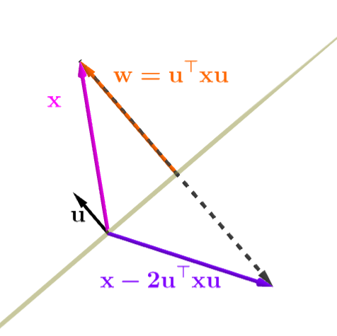

The projection of $\vec x$ on $\vec u$ (unit vector perpendicular to the plane) is a scalar multiple of $\vec u$, we find that $\vec w = \vec u \, \alpha$. It follows that $0 = \vec u^T\,(\vec x - \vec w) = \vec u^T\,(\vec x - \vec u\,\alpha)$. Therefore,

$$\alpha = \frac{\vec u^T \vec x}{\vec u^T
\vec u}$$

And substituting,

$$\vec w = \vec u \, \alpha = \frac{\vec
u\,\vec u^T}{\vec u^T \vec u} \vec x$$

Since $\vec u$ is of unit length,

$$\vec w = \vec u\,\vec u^T \, \vec x =
\vec u^T \vec x \vec u$$

as on the diagram above. And the reflection of $\vec x$ is:

$$\vec y = \vec x - 2\,\vec w\\ = \vec
x -2\,\vec u^T \vec x \, \vec u \\= \vec x -2\, \vec u \vec u^T \vec
x \\= (I - 2\, \vec u \vec u^T)\,\vec x$$

with the matrix $H = I - 2\,\vec u \vec u^T$ being the mirror or reflection matrix (aka a Householder transformation).

A YT presentation on this topic can be found [here](https://youtu.be/6TIVIw4B5VA?si=9v5Yclrm05TmIsPc).

Since we want to get an upper-triangular matrix $R$ in the intended $QR$ decomposition, the computation is carried out by successive sub-matrices such as in each one, the first column is of the form $\begin{bmatrix}a_1,0,0,\cdots\end{bmatrix}^\top$. Since the $H$ matrix is orthonormal, the transformation exerted by $H\vec x$ leaves the norm of $\vec x$ unchanged. We want a “mirror” such that the projection is along $e_1$ and of length $||\vec x||$. Given the equal norm of both $\vec x$ and $\vec y$, and with only one non-zero entry in $\vec y$, $\vec y= H\vec x = \beta \vec e_1 =\begin{bmatrix} \pm \lVert x\rVert&0&0&\cdots&0\end{bmatrix}$, imagining the reflection along the $x$ axis results in a simple expression for the difference vector $\vec v$:

$$\vec v = \vec x - \vec y=
\begin{bmatrix}x_1\\x_2\\x_3\\\vdots\\x_m\end{bmatrix} \pm \lVert x
\rVert \begin{bmatrix}1\\0\\0\\\vdots\\0\end{bmatrix}$$
Interestingly, this norm of $\vec x$ can be multiplied by $\pm 1$ or any complex number of norm $1,$ because it will only change the plane of symmetry of the reflection.

In the actual calculation of $R$, the procedure involves progressively nested sub-matrices, explaining why there is only one non-zero element in the first column matrix. This can be seen in the code below.

Having figured out $\vec v$ thus, the unit vector perpendicular to the plane of symmetry will be $\vec u= \frac{v}{\lVert v \rVert}$.

In the diagram below, the reflected vector is aligned with the $x$-axis, and we are trying to figure out the plane of reflection $\vec u.$

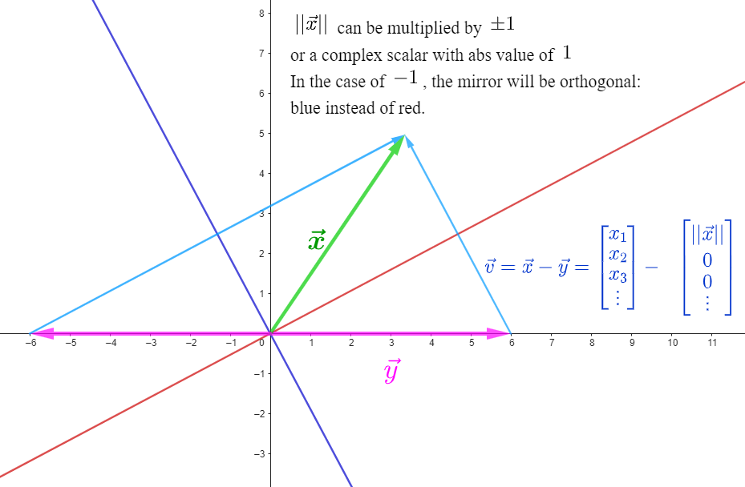

Source in [here](https://www.cs.utexas.edu/users/flame/laff/alaff/ALAFF.pdf)

From the diagrams above,

$$\vec x - 2 \vec w^\top \, \vec x \, \vec
w = \vec x - 2 \, \vec w \, \vec w \, \vec x = (\color{red}{1 - 2 \,
\vec w \, \vec w^\top})\, \vec x$$

In matrix form

$$(\color{red}{I - 2 \, \vec w\, \vec
w^\top})\, \vec x$$

In red is the matrix that captures the reflection like on a mirror, the so-called **Household transformation or reflector**.

What if we are interested in the mirror or dividing hyperplane given two vectors of equal magnitude?

$$\vec x = \vec v + \vec y$$

We want a sequence of unitary matrices such that

$$H_{n-1}\,\dots,H_0\, A = R$$

with $R$ being an upper triangular matrix:

$$H_0\,\begin{bmatrix}\circ& \cdots
& \circ \\ \vdots & \ddots & \circ \\
\circ & \cdots & \circ\end{bmatrix} = \begin{bmatrix}X&
\cdots & \circ \\ 0 & \ddots & \circ \\
0 & \cdots & \circ\end{bmatrix}$$

The matrix $H_0$ transforms the first column vector into a multiple of the first standard basis $\vec e_1 = \begin{bmatrix}X & 0 & 0 & \cdots \end{bmatrix}^\top$.

Calling the fist vector $x,$

$$H\,x = \beta \, e_0$$

$H$ preserves length, and therefore, $\vert \beta \vert = \Vert x\Vert_2.$

As stated above and apparent on the diagrams:

$$\vec v= \vec x - \vec y =
\begin{bmatrix}\chi_0\\\chi_1\\\vdots\\\chi_{n-1}\end{bmatrix}-
\begin{bmatrix} \Vert x \Vert \\0\\\vdots\\0\end{bmatrix}$$

Yet, $\beta$ can be the 2-norm of $x$, its negative or multiplied by any complex number of norm $1$.

So we have

$$\vec y =(I - 2 \vec w \vec w^\top)\,
\vec x = \beta \,\vec e_0$$

or

$$H\vec x = \pm \Vert x\Vert_2 \, \vec
e_0$$
Since as above

$$\vec v = x \pm \Vert x\Vert_2 \, \vec
e_0 = \begin{bmatrix}\chi_0 \pm \Vert x \Vert_2\\ \chi_1\\ \vdots \\
\chi_{m-1} \end{bmatrix}$$

it’s important to avoid catastrophic cancellation if the weight of the vector $x$ is concentrated on $\chi_0$ and we choose $-$. Therefore, we should make sure that we multiply $\Vert x\Vert_2$ by the $\text{sgn} (\chi_0)$.

Instead of the normalizing the vector $\vec v$ to get $\vec u = \frac{\vec v}{\Vert v\Vert},$ we can let $\vec v$ scale, and later normalize $\vec u$ as in

$$I - \tau\, u\,u^\top$$

with
$$\tau = \frac 2{1 + u^\top\,
u}$$

We want to scale $\vec v$ in a way that $\chi_0 \pm \Vert x\Vert_2 =1.$ Now $\vec u$ doesn’t have to be unitary. The vector $\vec u$ is the **Householder vector**. Modified (see code below) it is stored in the lower triangular matrix in the compact output of `qr()`.

Tau will also be stored in the output `qraux` as in the code below.

From the first column of the matrix $A,$ the Householder vector $\vec u$ is computed so that

$$(I - \tau_0\, u_0u_0^\top)\, A =
\begin{bmatrix}X& \cdots & \circ \\ 0 & \ddots & \circ
\\
0 & \cdots & \circ\end{bmatrix}$$

Next we leave the first row alone, and do the same procedure on the second column of the matrix resulting from multiplying $H_0A$:

$$\begin{bmatrix}X& \triangle
&\cdots & \circ \\ 0 & \square & \cdots & \circ\\0
&\color{red}\triangle & \ddots & \circ \\
0 & \color{red}\triangle & \cdots & \circ\end{bmatrix}
=\begin{bmatrix}X& \triangle &\cdots & \circ \\ 0 &
\color{blue}\square & \cdots & 0\\ 0 &\color{red}0 &
\ddots & \circ \\
0 & \color{red}0 & \cdots & \circ\end{bmatrix}$$

The function

$$\text{Houser} \begin{pmatrix}\chi_1 \\
x_2\end{pmatrix} = \begin{bmatrix}\begin{pmatrix} e\\ u_2 \end{pmatrix},
\tau \end{bmatrix}$$

with $\vec x = \begin{pmatrix}\chi_1 \\ x_2\end{pmatrix}$, $\begin{pmatrix} e\\ u_2 \end{pmatrix}$ the Householder vector with a $1$ as the first element. The computation of $e, u_2, \tau$ is so that

$$I - \tau \, \begin{pmatrix}1 \\ u_2
\end{pmatrix}\begin{pmatrix}1 \\ u_2 \end{pmatrix}^\top
\begin{pmatrix}\chi_1 \\ x_2\end{pmatrix} = \begin{pmatrix} e \\
0\end{pmatrix}$$

Expressed as block matrices:

$$\begin{pmatrix}
\bf I & \Bigg \vert & \bf 0 \\
\hline
\bf 0 & \Bigg \vert & I - \tau_1 \,
\begin{pmatrix}1\\u_{21}\end{pmatrix}\begin{pmatrix}1\\u_{21}\end{pmatrix}^\top
\end{pmatrix} \, \begin{pmatrix}
\bf R_{00} & \Bigg \vert & r_{01} & R_{02} \\
\hline
\\ & \Bigg \vert & \alpha_{11} & a_{12}^\top\\
\bf 0 & \Bigg \vert \\
& \Bigg \vert & a_{21} & A_{22}
\end{pmatrix}$$

#### Computation:

The function `House()` below has embedded some `print()` lines to reproduce the example elaborated in [here](https://www.r-bloggers.com/2017/04/qr-decomposition-with-householder-reflections/).

```r
House <- function(A) {
  require(Matrix)
  R <- as.matrix(A) # Set R to the input matrix A
  n <- ncol(A)
  m <- nrow(A)
  H <- list() # Initialize a list to store the computed H matrices to calculate Q later

  if (m > n) {c <- n} else {c <- m}
  for (k in 1:c) {
    x <- R[k:m, k] # Equivalent to a_1
    print(paste0("The HR for iteration ", k)); print(round(R, 2))
    print(paste0("The x for iteration ", k)); print(x)
    print(paste0("The x1 of the column matrix is ", x[1], " sign ", sign(x[1])))
    e1 <- as.matrix(c(1, rep(0, length(x) - 1))) # e_1
    vk <- x + sign(x[1]) * sqrt(sum(x^2)) * e1 # v as x + y
    print("The reflecion vec v = x + norm x e_1 is: "); print(x); print(" + "); print(as.vector(sign(x[1]) * sqrt(sum(x^2)) * e1)); print(" = "); print(as.vector(vk))

    # Compute the H matrix
    hk <- diag(length(x)) - 2 * as.vector(vk %*% t(vk)) / (t(vk) %*% vk) # I - 2 vv^T / vTv
    print("vv^T: "); print(round(vk %*% t(vk), 2))
    print("The hk is:"); print(round(hk, 2))
    if (k > 1) {# After the first matrix H a diagonal of 1's is added
      hk <- bdiag(diag(k - 1), hk)
      print("The hk matrix with 1's is:")
      print(hk)
    }
    # Store the H matrix to find Q at the end of iteration
    H[[k]] <- hk
    R <- hk %*% R # The first R is the actual A and it is updated as
                  # H H H H A
  }
  Q <- Reduce("%*%", H) # Calculate Q matrix by multiplying all H matrices
  res <- list('Q'= round(Q, 2),'R'= round(R, 2))
  return(res)
}
```

Now with the input from [here](https://www.r-bloggers.com/2017/04/qr-decomposition-with-householder-reflections/):

$$A = \begin{bmatrix} 2 & – 2 & 18
\\\ 2 & 1 & 0 \\\ 1 & 2 & 0 \end{bmatrix}$$

The first column vector, i.e. $a_1 = \begin{bmatrix}2 & 2 & 1 \end{bmatrix}^T$ will be reflected to $\vec x - \vec y$. But we can instead of using $-||x||$ we can use that value times $-1$ and calculate $\vec x + ||x||\,\vec e_1$:

$$\vec v_1 =
\begin{bmatrix}2\\2\\1\end{bmatrix} + \left( \sum_{k=1}^m a_1^2
\right)^{1/2} \, \begin{bmatrix} 1 \\ 0 \\ 0 \end{bmatrix} =
\begin{bmatrix}5 \\ 2 \\ 1\end{bmatrix}$$

The next step is calculating $I - 2 \frac{vv^\top}{v^\top v}$:

$$H_1= \small
\begin{bmatrix}1&0&0\\0&1&0\\0&0&1\end{bmatrix}
- 2
\frac{\begin{bmatrix}5&2&1\end{bmatrix}\begin{bmatrix}5\\2\\1\end{bmatrix}}{\begin{bmatrix}5\\2\\1\end{bmatrix}\begin{bmatrix}5&2&1\end{bmatrix}}=\begin{bmatrix}
-\frac{2}{3} & -\frac{2}{3} & -\frac{1}{3} \\\ -\frac{2}{3}
& 0.7333 & -0.1333 \\\ -\frac{1}{3} & -0.1333 & 0.9333
\end{bmatrix}$$

This is then multiplied $H_1A$:

$$H_1 A = \small \begin{bmatrix}
-\frac{2}{3} & -\frac{2}{3} & -\frac{1}{3} \\\ -\frac{2}{3}
& 0.7333 & -0.1333 \\\ -\frac{1}{3} & -0.1333 & 0.9333
\end{bmatrix} \begin{bmatrix} 2 & – 2 & 18 \\\ 2 & 1 & 0
\\\ 1 & 2 & 0 \end{bmatrix} = \begin{bmatrix} -3 & 0 &
-12 \\\ 0 & 1.8 & 12 \\\ 0 & 2.4 & -6
\end{bmatrix}$$

$H_1A$ replaces $A$ in the next iteration. Now comes to $a_2$ and $H_2$ with the submatrix of $A$

$$A^{(1)} = \begin{bmatrix} 1.8 & 12
\\\ 2.4 & -6 \end{bmatrix}$$
$v_2$ is

$$\small \begin{bmatrix} 1.8 \\\ 2.4
\end{bmatrix} + \sqrt{\sum^m_{j=1} a_2^2} \begin{bmatrix} 1 \\\ 0
\end{bmatrix} = \begin{bmatrix} 4.8 \\\ 2.4 \end{bmatrix}$$

The $H_2$ Householder matrix is

$$H_2 = \small \begin{bmatrix} 1 & 0
\\\ 0 & 1 \end{bmatrix} – 2 \frac{\begin{bmatrix} 4.8 & 2.4
\end{bmatrix} \begin{bmatrix} 4.8 \\\ 2.4 \end{bmatrix}}{\begin{bmatrix}
4.8 \\\ 2.4 \end{bmatrix} \begin{bmatrix} 4.8 & 2.4
\end{bmatrix}}=\begin{bmatrix} 1 & 0 & 0 \\\ 0 & -0.6 &
-0.8 \\\ 0 & -0.8 & 0.6 \end{bmatrix}$$

The first column $\begin{bmatrix}1 \\\ 0 \\\ 0 \end{bmatrix}$ and first row $\begin{bmatrix}1 & 0 & 0 \end{bmatrix}$ are added to the resulting $H_2$ matrix to keep it $n \times n$.

Now

$$H_2 = \begin{bmatrix} 1 & 0 & 0
\\\ 0 & -0.6 & -0.8 \\\ 0 & -0.8 & 0.6 \end{bmatrix}
\begin{bmatrix} -3 & 0 & -12 \\\ 0 & 1.8 & 12 \\\ 0
& 2.4 & -6 \end{bmatrix}=\begin{bmatrix} -3 & 0 & -12
\\\ 0 & -3 & 12 \\\ 0 & 0 & 6 \end{bmatrix}$$

Moving to $a_3$ and $H_3$, the submatrix of $H_2A$ is simply $[6]$. Therefore, $v_3$ is equal to:

$$\begin{bmatrix} 6 \end{bmatrix} – \small
\sqrt{\sum^m_{j=1} a_3^2} \begin{bmatrix} 1 \end{bmatrix} =
12$$

The $H_3$

$$H_3 = \small \begin{bmatrix} 1
\end{bmatrix} – 2 \frac{\begin{bmatrix} 12 \end{bmatrix}\begin{bmatrix}
12 \end{bmatrix}}{\begin{bmatrix} 12 \end{bmatrix}\begin{bmatrix} 12
\end{bmatrix}} = \begin{bmatrix}1 & 0 & 0 \\\ 0 & 1 & 0
\\\ 0 & 0 & -1 \end{bmatrix}$$

and

$$H_3 A = \small \begin{bmatrix}1 & 0
& 0 \\\ 0 & 1 & 0 \\\ 0 & 0 & -1 \end{bmatrix}
\begin{bmatrix} -3 & 0 & -12 \\\ 0 & -3 & 12 \\\ 0 &
0 & 6 \end{bmatrix} = \begin{bmatrix} -3 & 0 & -12 \\\ 0
& -3 & 12 \\\ 0 & 0 & -6 \end{bmatrix}$$

Which is the $R$ factorization in the $QR$ decomposition method. The $Q$ factorization of $QR$ decomposition is found by multiplying all the $H$ matrices together

$$Q = \small \begin{bmatrix} -\frac{2}{3}
& -\frac{2}{3} & -\frac{1}{3} \\\ -\frac{2}{3} & 0.7333
& -0.1333 \\\ -\frac{1}{3} & -0.1333 & 0.9333 \end{bmatrix}
\begin{bmatrix} 1 & 0 & 0 \\\ 0 & -0.6 & -0.8 \\\ 0
& -0.8 & 0.6 \end{bmatrix} \begin{bmatrix}1 & 0 & 0 \\\
0 & 1 & 0 \\\ 0 & 0 & -1 \end{bmatrix}= \begin{bmatrix}
-\frac{2}{3} & \frac{2}{3} & -\frac{1}{3} \\\ -\frac{2}{3} &
-\frac{1}{3} & \frac{2}{3} \\\ -\frac{1}{3} & -\frac{2}{3} &
-\frac{2}{3} \end{bmatrix}$$

```r
A <- rbind(c(2,-2,18),c(2,1,0),c(1,2,0))
(hse <- House(A))
```

```
## [1] "The HR for iteration 1"
##      [,1] [,2] [,3]
## [1,]    2   -2   18
## [2,]    2    1    0
## [3,]    1    2    0
## [1] "The x for iteration 1"
## [1] 2 2 1
## [1] "The x1 of the column matrix is 2 sign 1"
## [1] "The reflecion vec v = x + norm x e_1 is: "
## [1] 2 2 1
## [1] " + "
## [1] 3 0 0
## [1] " = "
## [1] 5 2 1
## [1] "vv^T: "
```

[output cut: 64 more lines]

```
## $Q
## 3 x 3 Matrix of class "dgeMatrix"
##       [,1]  [,2]  [,3]
## [1,] -0.67  0.67 -0.33
## [2,] -0.67 -0.33  0.67
## [3,] -0.33 -0.67 -0.67
##
## $R
## 3 x 3 Matrix of class "dgeMatrix"
##      [,1] [,2] [,3]
## [1,]   -3    0  -12
## [2,]    0   -3   12
## [3,]    0    0   -6
```

Now comparing to built-in functions:

```r
round(qr.Q(qr(A)), 2); round(qr.R(qr(A)), 2)
```

```
##       [,1]  [,2]  [,3]
## [1,] -0.67  0.67  0.33
## [2,] -0.67 -0.33 -0.67
## [3,] -0.33 -0.67  0.67
```

```
##      [,1] [,2] [,3]
## [1,]   -3    0  -12
## [2,]    0   -3   12
## [3,]    0    0    6
```

Analyzing the result of `qr()`, note that `qr` is a matrix with the same dimensions as the input `x`. The upper triangle contains the $R$ of the decomposition and the lower triangle contains information on the $Q$ of the decomposition.

```r
(QR <- round(as.matrix(qr(A)$qr), 2))
```

```
##       [,1] [,2] [,3]
## [1,] -3.00  0.0  -12
## [2,]  0.67 -3.0   12
## [3,]  0.33  0.8    6
```

```r
# Excluding the lower triangular entries returns R:
QR[row(QR) > col(QR)] = 0; QR
```

```
##      [,1] [,2] [,3]
## [1,]   -3    0  -12
## [2,]    0   -3   12
## [3,]    0    0    6
```

```r
# To get Q:
round(Q <- qr.Q(qr(A)), 2)
```

```
##       [,1]  [,2]  [,3]
## [1,] -0.67  0.67  0.33
## [2,] -0.67 -0.33 -0.67
## [3,] -0.33 -0.67  0.67
```

```r
# Notice that Q is orthonormal:
round(t(Q)%*%Q, 2)
```

```
##      [,1] [,2] [,3]
## [1,]    1    0    0
## [2,]    0    1    0
## [3,]    0    0    1
```

To replicate the lower triangular matrix in the output of R for `qr()` as well as `qraux`:

Source in [here](https://www.cs.utexas.edu/users/flame/laff/alaff/ALAFF.pdf)

Formulas:

`qraux` entries contain the `tau` values obtained for each H sub-matrix:

$$\tau = \frac{2}{1 + \vec u^\top\,\vec
u}$$

such that it is the scalar factor in the Householder matrix:

$$I - \tau \,\vec u\, \vec
u^\top$$

and the vector $\vec u$ is the Householder vector from the leading column:

$$\vec u = x /\nu$$

with

$$\nu = \chi_1 +
\text{sign}(\chi_1)\,\Vert x\Vert_2 = \chi_1 + \text{sign}(\chi_1)\,
\sqrt{\sum_i x_i^2}$$

where $\chi_1$ is the leading entry in the column vector, and $\Vert x \Vert_2$ the square root of the 2-norm of the leading column vector in the sub-matrices.

```r
set.seed(2024)
options(digits=10)

# Since it's about understanding the convention of the qr()
# I'm sticking to square matrices. s is the number of rows and cols:
s = 4
m = matrix(rnorm(s^2), nrow = s)
# chi1 is the leading entry of each col vector in the matrix m (aka as A)
# keeping in mind that the matrix will be updated in a loop
# by multiplying it on the left by the Householder matrices:
chi1 = m[1,1] # This is the initial entry out of the original matrix.
# The initial col vector is precisely the first col in the orig. mat.
# And its 2-norm is:
norm = sqrt(sum(m[,1]^2))
# The Householder vector will be constructed by taking the entries of
# the column matrix at each iteration of the products H H H A
# below the leading entry in the decreasing sub-matrices (chi1):
x2 = m[2:nrow(m), 1] # This is the initial one.
# nu1 is the difference between the original vector and the mirror image
# avoiding catastrophic cancellation, ie chi1 + norm(x) * e_1:
nu1 = chi1 + sign(chi1) * norm
# nu1 will standardize u2:
u2 = x2 / nu1
# Let's see this applied to this first column vector in the matrix A
(tau = 2 / (1 + t(u2)%*%u2))
```

```
##             [,1]
## [1,] 1.881503125
```

```r
# Now let's get all the values of the output in qraux and in the lower
# triangular matrix of the output:
# Initializing a vector to collect values below the diag
# They will be output with a sign difference wrt to the R base function.
lwrT = matrix(0, s, s)
# Initializing an empty vector to collect the values of qraux:
qraux <- numeric()
A = m
r = nrow(m)
for (i in 1:r){
  chi1 = A[i,i]
  norm = sqrt(sum(A[i:r, i]^2))
  if(i < r){x2 = as.matrix(A[(i + 1):r, i])}else{x2 = 0}
  nu1 = chi1 + sign(chi1) * norm
  u2 = x2 / nu1
  if(i < r){tau = 2 / (1 + t(u2) %*% u2)}else{tau = sign(chi1) * nu1 / 2}
  qraux[i] = tau
  if(i < r) {augm = c(rep(0, i - 1), 1, u2)}
          else
            {augm = c(rep(0, i - 1), 0)}
  H <- diag(r) - as.numeric(tau) *
    outer(as.vector(augm), as.vector(t(augm)),'*')
  if(i < r){lwrT[(i + 1):r, i] <- - H[(i + 1):r, i]}else{}
  A <- H %*% A
}
# After all iterations multiplying H A we end up producing
# R or the upper triangular (including the diagonal in qr()):
round(A,9)
```

```
##             [,1]         [,2]        [,3]         [,4]
## [1,] -1.11397156 -1.537094686 1.479110318 -1.202532687
## [2,]  0.00000000 -0.975037638 1.587258014  2.295022409
## [3,]  0.00000000  0.000000000 1.032380986  2.124104691
## [4,]  0.00000000  0.000000000 0.000000000 -0.544290993
```

```r
# The lower triangular containing essentially tau * uTu:
lwrT
```

```
##               [,1]         [,2]          [,3] [,4]
## [1,]  0.0000000000 0.0000000000  0.0000000000    0
## [2,]  0.4207603289 0.0000000000  0.0000000000    0
## [3,] -0.0969246757 0.6907309238  0.0000000000    0
## [4,] -0.1910983876 0.1504635437 -0.3677919994    0
```

```r
# They fit perfectly to replicate the output of qr():
qr(m)$qr
```

```
##               [,1]          [,2]          [,3]          [,4]
## [1,] -1.1139715602 -1.5370946856  1.4791103176 -1.2025326872
## [2,]  0.4207603289 -0.9750376385  1.5872580139  2.2950224086
## [3,] -0.0969246757  0.6907309238  1.0323809861  2.1241046912
## [4,] -0.1910983876  0.1504635437 -0.3677919994 -0.5442909928
```

```r
# Likewise the output of the vector in the calculations above
# for tau:
qraux
```

```
## [1] 1.8815031249 1.7072846053 1.9299080843 0.5442909928
```

```r
# replicate the built-in function qraux:
qr(m)$qraux
```

```
## [1] 1.8815031249 1.7072846053 1.9299080843 0.5442909928
```

[Home Page](http://rinterested.github.io/statistics/index.html)

**NOTE: These are tentative notes on different topics for personal use - expect mistakes and misunderstandings.**